# Project Notes 1

## Problem Statement

An aviation company that provides domestic as well as international trips to the customers now wants to apply a targeted approach instead of reaching out to each of the customers. This time they want to do it digitally instead of tele-calling. Hence they have collaborated with a social networking platform, so they can learn the digital and social behavior of the customers and provide the digital advertisement on the user page of the targeted customers who have a high propensity to take up the product. Propensity of buying tickets is different for different login devices. Hence, you have to create 2 models separately for Laptop and Mobile. [Anything which is not a laptop can be considered as mobile phone usage.] The advertisements on the digital platform are bit expensive, hence you need to be very accurate while creating the models.

## Importing Libraries and Checking the Data

```python
#Importing basic Libraries

import numpy as np
import pandas as pd
import seaborn as sns
import matplotlib.pyplot as plt
%matplotlib inline

#to ignore warnings
import warnings
warnings.filterwarnings('ignore')
```

```python
#Loading the dataset

data = pd.read_csv(r'D:\SHUBHANK !\GL\My_Capstone_Project\Social Media Data for DSBA.csv')
```

## Exploring the data

```python
#Reading the head of the dataset

data.head()
```

|  | UserID | Taken_product | Yearly_avg_view_on_travel_page | preferred_device | total_likes_on_outstation_checkin_given | yearly_avg_Outstation_checkins | member_in_family | preferred_location_type | Yearly_avg_comment_on_travel_page | total_likes_on_outofstation_checkin_received | week_since_last_outstation_checkin | following_company_page | montly_avg_comment_on_company_page | working_flag | travelling_network_rating | Adult_flag | Daily_Avg_mins_spend_on_traveling_page |
| --- | --- | --- | --- | --- | --- | --- | --- | --- | --- | --- | --- | --- | --- | --- | --- | --- | --- |
| 0 | 1000001 | Yes | 307.0 | iOS and Android | 38570.0 | 1 | 2 | Financial | 94.0 | 5993 | 8 | Yes | 11 | No | 1 | 0 | 8 |
| 1 | 1000002 | No | 367.0 | iOS | 9765.0 | 1 | 1 | Financial | 61.0 | 5130 | 1 | No | 23 | Yes | 4 | 1 | 10 |
| 2 | 1000003 | Yes | 277.0 | iOS and Android | 48055.0 | 1 | 2 | Other | 92.0 | 2090 | 6 | Yes | 15 | No | 2 | 0 | 7 |
| 3 | 1000004 | No | 247.0 | iOS | 48720.0 | 1 | 4 | Financial | 56.0 | 2909 | 1 | Yes | 11 | No | 3 | 0 | 8 |
| 4 | 1000005 | No | 202.0 | iOS and Android | 20685.0 | 1 | 1 | Medical | 40.0 | 3468 | 9 | No | 12 | No | 4 | 1 | 6 |

```python
#Printing the shape of the dataset

print('Total Columns: ',data.shape[1])
print('Total Rows: ',data.shape[0])
```

```
Total Columns:  17
Total Rows:  11760
```

```python
#Let see all the names of the columns in the dataset

data.columns
```

```
Index(['UserID', 'Taken_product', 'Yearly_avg_view_on_travel_page',
       'preferred_device', 'total_likes_on_outstation_checkin_given',
       'yearly_avg_Outstation_checkins', 'member_in_family',
       'preferred_location_type', 'Yearly_avg_comment_on_travel_page',
       'total_likes_on_outofstation_checkin_received',
       'week_since_last_outstation_checkin', 'following_company_page',
       'montly_avg_comment_on_company_page', 'working_flag',
       'travelling_network_rating', 'Adult_flag',
       'Daily_Avg_mins_spend_on_traveling_page'],
      dtype='object')
```

#### Renaming few of the columns for better readability and understanding

Replacing few long words in short abbreviations, like:

1. Yearly_avg as YA
2. Daily_avg as DA
3. Preffered as Pref
4. Total_likes as TL
5. Monthly_avg as MA
6. Outstation or out of station are same, so replacing it with OS
7. Travel_page and Company_page are same, so replacing it with CP

```python
data.rename({'Yearly_avg_view_on_travel_page': 'YA_view_on_CP',
             'preferred_device': 'pref_device',
            'total_likes_on_outstation_checkin_given': 'TL_done_on_OS_checkin',
            'yearly_avg_Outstation_checkins' : 'YA_OS_checkin',
            'member_in_family' : 'members_in_fam',
            'preferred_location_type' : 'pref_loc_type',
            'Yearly_avg_comment_on_travel_page' : 'YA_comment_on_CP',
            'total_likes_on_outofstation_checkin_received' : 'TL_rec_on_OS_checkin',
            'week_since_last_outstation_checkin' : 'week_since_last_OS_checkin',
            'following_company_page' : 'following_CP',
            'montly_avg_comment_on_company_page':'MA_comment_on_CP',
            'Daily_Avg_mins_spend_on_traveling_page' : 'DA_mins_spend_on_CP'}, axis=1, inplace=True)
```

```python
#Now again checking columns and shape

print(data.shape)
print('\n---------------')
new_column_names = data.columns
print(new_column_names)
```

```
(11760, 17)

---------------
Index(['UserID', 'Taken_product', 'YA_view_on_CP', 'pref_device',
       'TL_done_on_OS_checkin', 'YA_OS_checkin', 'members_in_fam',
       'pref_loc_type', 'YA_comment_on_CP', 'TL_rec_on_OS_checkin',
       'week_since_last_OS_checkin', 'following_CP', 'MA_comment_on_CP',
       'working_flag', 'travelling_network_rating', 'Adult_flag',
       'DA_mins_spend_on_CP'],
      dtype='object')
```

```python
#Size of the dataset

data.size
```

```
199920
```

```python
#Let's look at the basic information about the dataset

data.info()
```

```
<class 'pandas.core.frame.DataFrame'>
RangeIndex: 11760 entries, 0 to 11759
Data columns (total 17 columns):
 #   Column                      Non-Null Count  Dtype
---  ------                      --------------  -----
 0   UserID                      11760 non-null  int64
 1   Taken_product               11760 non-null  object
 2   YA_view_on_CP               11179 non-null  float64
 3   pref_device                 11707 non-null  object
 4   TL_done_on_OS_checkin       11379 non-null  float64
 5   YA_OS_checkin               11685 non-null  object
 6   members_in_fam              11760 non-null  object
 7   pref_loc_type               11729 non-null  object
 8   YA_comment_on_CP            11554 non-null  float64
 9   TL_rec_on_OS_checkin        11760 non-null  int64
 10  week_since_last_OS_checkin  11760 non-null  int64
 11  following_CP                11657 non-null  object
 12  MA_comment_on_CP            11760 non-null  int64
 13  working_flag                11760 non-null  object
 14  travelling_network_rating   11760 non-null  int64
 15  Adult_flag                  11760 non-null  int64
 16  DA_mins_spend_on_CP         11760 non-null  int64
dtypes: float64(3), int64(7), object(7)
memory usage: 1.5+ MB
```

```python
#Description of the data and five number summary using describe function

pd.set_option('display.float_format', lambda x: '%.2f' % x) #Keeping the decimal points upto 2 places
data.describe().T
```

|  | count | mean | std | min | 25% | 50% | 75% | max |
| --- | --- | --- | --- | --- | --- | --- | --- | --- |
| UserID | 11760.00 | 1005880.50 | 3394.96 | 1000001.00 | 1002940.75 | 1005880.50 | 1008820.25 | 1011760.00 |
| YA_view_on_CP | 11179.00 | 280.83 | 68.18 | 35.00 | 232.00 | 271.00 | 324.00 | 464.00 |
| TL_done_on_OS_checkin | 11379.00 | 28170.48 | 14385.03 | 3570.00 | 16380.00 | 28076.00 | 40525.00 | 252430.00 |
| YA_comment_on_CP | 11554.00 | 74.79 | 24.03 | 3.00 | 57.00 | 75.00 | 92.00 | 815.00 |
| TL_rec_on_OS_checkin | 11760.00 | 6531.70 | 4706.61 | 1009.00 | 2940.75 | 4948.00 | 8393.25 | 20065.00 |
| week_since_last_OS_checkin | 11760.00 | 3.20 | 2.62 | 0.00 | 1.00 | 3.00 | 5.00 | 11.00 |
| MA_comment_on_CP | 11760.00 | 28.66 | 48.66 | 11.00 | 17.00 | 22.00 | 27.00 | 500.00 |
| travelling_network_rating | 11760.00 | 2.71 | 1.08 | 1.00 | 2.00 | 3.00 | 4.00 | 4.00 |
| Adult_flag | 11760.00 | 0.79 | 0.85 | 0.00 | 0.00 | 1.00 | 1.00 | 3.00 |
| DA_mins_spend_on_CP | 11760.00 | 13.82 | 9.07 | 0.00 | 8.00 | 12.00 | 18.00 | 270.00 |

```python
#Checking the data type for each variable in the dataset

data.dtypes
```

```
UserID                          int64
Taken_product                  object
YA_view_on_CP                 float64
pref_device                    object
TL_done_on_OS_checkin         float64
YA_OS_checkin                  object
members_in_fam                 object
pref_loc_type                  object
YA_comment_on_CP              float64
TL_rec_on_OS_checkin            int64
week_since_last_OS_checkin      int64
following_CP                   object
MA_comment_on_CP                int64
working_flag                   object
travelling_network_rating       int64
Adult_flag                      int64
DA_mins_spend_on_CP             int64
dtype: object
```

```python
#Any null or missing values in dataset ?? Let's check

data.isnull().any()
```

```
UserID                        False
Taken_product                 False
YA_view_on_CP                  True
pref_device                    True
TL_done_on_OS_checkin          True
YA_OS_checkin                  True
members_in_fam                False
pref_loc_type                  True
YA_comment_on_CP               True
TL_rec_on_OS_checkin          False
week_since_last_OS_checkin    False
following_CP                   True
MA_comment_on_CP              False
working_flag                  False
travelling_network_rating     False
Adult_flag                    False
DA_mins_spend_on_CP           False
dtype: bool
```

Boolean value False means there is no missing data in the column and True means there are some missing values in that column.

```python
#Yes, there are missing values in the dataset.

#let's check how many missing values are there in those columns

data.isnull().sum()
```

```
UserID                          0
Taken_product                   0
YA_view_on_CP                 581
pref_device                    53
TL_done_on_OS_checkin         381
YA_OS_checkin                  75
members_in_fam                  0
pref_loc_type                  31
YA_comment_on_CP              206
TL_rec_on_OS_checkin            0
week_since_last_OS_checkin      0
following_CP                  103
MA_comment_on_CP                0
working_flag                    0
travelling_network_rating       0
Adult_flag                      0
DA_mins_spend_on_CP             0
dtype: int64
```

```python
#Total count of the missing values

print('Total missing values:',data.isnull().sum().sum())
```

```
Total missing values: 1430
```

## Data Cleaning

#### Dropping 2 columns

```python
#First of all dropping the UserID column as it is not so useful for our analysis
#Also we are dropping montly_avg_comment_on_company_page column bceause we already have yearly_avg comment column because
#it does not make sense to keep both columns as it is indicating same action

data.drop(['UserID','MA_comment_on_CP'], axis = 1, inplace = True)
```

#### Treating Missing Values

```python
#While checking, we've got 1430 total missing values in the dataset, which is around 12% of the total records
#So we decide not to do any random imputation because it may affect our model

#Lets just drop them all

data.dropna(inplace=True)
```

```python
#After dropping, Let's check the null values again

data.isnull().sum()
```

```
Taken_product                 0
YA_view_on_CP                 0
pref_device                   0
TL_done_on_OS_checkin         0
YA_OS_checkin                 0
members_in_fam                0
pref_loc_type                 0
YA_comment_on_CP              0
TL_rec_on_OS_checkin          0
week_since_last_OS_checkin    0
following_CP                  0
working_flag                  0
travelling_network_rating     0
Adult_flag                    0
DA_mins_spend_on_CP           0
dtype: int64
```

Now all the null values are dropped from the dataset.

```python
#Let's check the shape and info again

print('Total Columns: ',data.shape[1])
print('Total Rows: ',data.shape[0])
print('\n------------')
data.info()
```

```
Total Columns:  15
Total Rows:  10456

------------
<class 'pandas.core.frame.DataFrame'>
Int64Index: 10456 entries, 0 to 11759
Data columns (total 15 columns):
 #   Column                      Non-Null Count  Dtype
---  ------                      --------------  -----
 0   Taken_product               10456 non-null  object
 1   YA_view_on_CP               10456 non-null  float64
 2   pref_device                 10456 non-null  object
 3   TL_done_on_OS_checkin       10456 non-null  float64
 4   YA_OS_checkin               10456 non-null  object
 5   members_in_fam              10456 non-null  object
 6   pref_loc_type               10456 non-null  object
 7   YA_comment_on_CP            10456 non-null  float64
 8   TL_rec_on_OS_checkin        10456 non-null  int64
 9   week_since_last_OS_checkin  10456 non-null  int64
 10  following_CP                10456 non-null  object
 11  working_flag                10456 non-null  object
 12  travelling_network_rating   10456 non-null  int64
 13  Adult_flag                  10456 non-null  int64
 14  DA_mins_spend_on_CP         10456 non-null  int64
dtypes: float64(3), int64(5), object(7)
memory usage: 1.3+ MB
```

Now there are 10456 records and no null/missing values present.

#### Dropping the rows which has special characters

While checking the dataset, we found out that there is a special character in the column 'YA_OS_checkin'. So let's drop the rows with special character.

```python
#First checking the row with special character in the column
data[data.YA_OS_checkin.str.contains(r'[@#&$%+-/*]')]

#dropping the complete row
data.drop(data[data.YA_OS_checkin.str.contains(r'[^0-9a-zA-Z]')].index, inplace=True)
```

```python
#reprinting the shape now

data.shape
```

```
(10455, 15)
```

Now we are left with have 10455 rows and 15 columns.

## Let's do the Univariate Analysis

```python
#Taken_product (Whether the user has taken their product or not)

print(data.Taken_product.value_counts())
print('\n---------------')
print('Proportion:\n',data.Taken_product.value_counts(normalize=True))
```

```
No     8762
Yes    1693
Name: Taken_product, dtype: int64

---------------
Proportion:
 No    0.84
Yes   0.16
Name: Taken_product, dtype: float64
```

84% people did not take the product. This means that data is not balanced. We will deal with problem later.

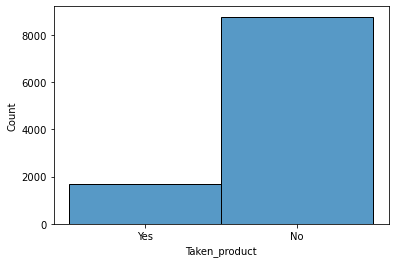

```python
#Histogram for Taken_product

sns.histplot(data=data, x="Taken_product")
```

```python
#Pref_device (Preferred device of the user through which user do login)

print(data.pref_device.value_counts())
print('\n---------------')
print('Proportion: \n',data.pref_device.value_counts(normalize=True))
```

```
Tab                4172
iOS and Android    3246
Laptop             1108
iOS                 859
Mobile              600
Android             244
Android OS          126
ANDROID              97
Other                 2
Others                1
Name: pref_device, dtype: int64

---------------
Proportion:
 Tab               0.40
iOS and Android   0.31
Laptop            0.11
iOS               0.08
Mobile            0.06
Android           0.02
Android OS        0.01
ANDROID           0.01
Other             0.00
Others            0.00
Name: pref_device, dtype: float64
```

#### We can see there are so many devices mentioned in the dataset. But as per the information provided in the problem statement that 'Anything which is not a laptop can be considered as mobile phone usage', so we will replace everything with mobile except Laptop.

```python
data['pref_device'].replace({'Tab': 'Mobile', 'iOS and Android': 'Mobile', 'iOS': 'Mobile',
                            'Android': 'Mobile', 'Android OS': 'Mobile', 'ANDROID': 'Mobile',
                            'iOS and Android': 'Mobile', 'Other': 'Mobile', 'Others': 'Mobile'}, inplace=True)
```

```python
#Now again checking pref_device column

print(data.pref_device.value_counts())
print('\n---------------')
print('Proportion: \n',data.pref_device.value_counts(normalize=True))
```

```
Mobile    9347
Laptop    1108
Name: pref_device, dtype: int64

---------------
Proportion:
 Mobile   0.89
Laptop   0.11
Name: pref_device, dtype: float64
```

This indicates that 89% of the people in our data use Mobile as their preferred device.

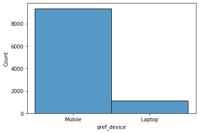

```python
#Histogram for pref_device

sns.histplot(data=data, x="pref_device")
```

```python
#Pref_loc_type  (Preferred location type of the user)

print(data.pref_loc_type.value_counts())
```

```
Beach              2424
Financial          1875
Historical site    1856
Medical            1448
Big Cities          636
Other               581
Trekking            528
Social media        506
Entertainment       383
Hill Stations       108
Tour  Travel         53
Tour and Travel      37
Game                 10
OTT                   6
Movie                 4
Name: pref_loc_type, dtype: int64
```

We can see that there are various preferred location type available in the data. Let's assign few of them into one category and organize these.

1. We will take Beach, Historical site, Trekking, Tour Travel, Tour and Travel and Hill Stations in one category and will name it 'Adventure and Tourism'.
2. We will be replacing Game, OTT, Movie and Social Media with one already available category Entertainment.

```python
data['pref_loc_type'].replace({'Beach': 'Adventure and Tourism','Historical site': 'Adventure and Tourism',
                               'Trekking': 'Adventure and Tourism', 'Tour  Travel': 'Adventure and Tourism',
                               'Tour and Travel': 'Adventure and Tourism', 'Hill Stations': 'Adventure and Tourism',
                               'Game': 'Entertainment', 'OTT': 'Entertainment', 'Movie': 'Entertainment',
                              'Social media': 'Entertainment'}, inplace=True)
```

```python
#Checking the updated values and checking the proportion for each

print(data.pref_loc_type.value_counts())
print('\n---------------')
print('Proportion: \n',data.pref_loc_type.value_counts(normalize=True))
```

```
Adventure and Tourism    5006
Financial                1875
Medical                  1448
Entertainment             909
Big Cities                636
Other                     581
Name: pref_loc_type, dtype: int64

---------------
Proportion:
 Adventure and Tourism   0.48
Financial               0.18
Medical                 0.14
Entertainment           0.09
Big Cities              0.06
Other                   0.06
Name: pref_loc_type, dtype: float64
```

So after organizing the categories, we found out that 'Adventure and Tourism' is the most preferred location type with 48%. Then 18% of the user has 'Financial' as their preferred location type, because they might travel mostly for business purpose. Then comes the 'Medical' as preferred location, as 14% of the user travel for their medical purposes. Only 9% of the users has 'Entertainment' as their preferred location type.

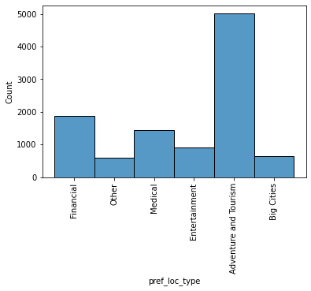

```python
#Histogram for pref_loc_type

plt.xticks(rotation=90)
sns.histplot(data=data, x="pref_loc_type")
```

```python
#Following_CP (whether the user is following the company page or not)

print(data.following_CP.value_counts())
```

```
No     7517
Yes    2923
1        10
0         5
Name: following_CP, dtype: int64
```

Here we need the data in the form of 'Yes' and 'No'. So we need to replace numeric value of 1 to Yes and 0 to No.

```python
#replacing 1 and 0 with Yes and No respectively.

data['following_CP'].replace({'1': 'Yes', '0': 'No'}, inplace=True)
```

```python
#Again checking

print(data.following_CP.value_counts())
print('\n---------------')
print('Proportion: \n',data.following_CP.value_counts(normalize = True))
```

```
No     7522
Yes    2933
Name: following_CP, dtype: int64

---------------
Proportion:
 No    0.72
Yes   0.28
Name: following_CP, dtype: float64
```

We see that only 28% of the users are following the company page and 72% still do not follow.

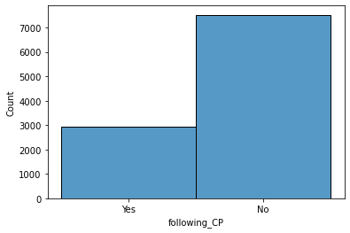

```python
#Histogram for following_CP

sns.histplot(data=data, x="following_CP")
```

```python
#Working_flag (whether the user is working somewhere or not)

print(data.working_flag.value_counts())
print('\n---------------')
print('Proportion: \n',data.working_flag.value_counts(normalize = True))
```

```
No     8846
Yes    1609
Name: working_flag, dtype: int64

---------------
Proportion:
 No    0.85
Yes   0.15
Name: working_flag, dtype: float64
```

85% of the users do not work anywhere. Only 15% users are working.

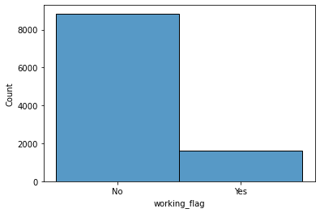

```python
#Histogram for working_flag

sns.histplot(data=data, x="working_flag")
```

```python
#members_in_fam (Number of members in the family of the user)

data.members_in_fam.value_counts()
```

```
3        4087
4        2843
2        1983
1        1192
5         331
10         10
Three       9
Name: members_in_fam, dtype: int64
```

Instead of numeric 3, it is in alphabet form, let's replace/correct it.

```python
data['members_in_fam'].replace({'Three': '3'}, inplace=True)
```

```python
data.members_in_fam.value_counts()
```

```
3     4096
4     2843
2     1983
1     1192
5      331
10      10
Name: members_in_fam, dtype: int64
```

Most of the users have 3 members in their family.

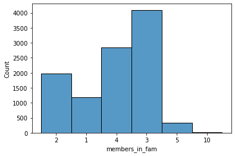

```python
#Histogram for members_in_fam

sns.histplot(data=data, x="members_in_fam")
```

```python
#Adult_flag (Whether the user is Adult or not)
#it should be either only 0 and 1, where 0 means user is not adult and 1 means user is adult.

data.Adult_flag.value_counts()
```

```
0    4476
1    4248
2    1114
3     617
Name: Adult_flag, dtype: int64
```

```python
#here we will replace 2 and 3 with 1 because it's a categorical variable which must have only 2 options
#User can either be adult or not, so it should have values of either yes and no, or 1 and 0 and it can't be 2 and 3 in it  .

data['Adult_flag'].replace({2: 1, 3: 1}, inplace=True)
```

```python
#Now checking again

data.Adult_flag.value_counts()
```

```
1    5979
0    4476
Name: Adult_flag, dtype: int64
```

```python
data.Adult_flag.value_counts(normalize=True)
```

```
1   0.57
0   0.43
Name: Adult_flag, dtype: float64
```

Around 57% users are adult.

#### Correcting the data types of few of the data columns

As we have checked that few variables indicating the incorrect data types like:

1. 'YA_view_on_CP' should have integer type instead of float type.
2. 'TL_done_on_OS_checkin' should have integer type instead of float type.
3. 'YA_OS_checkin' should have integer type instead of object type.
4. 'members_in_fam' should have integer type instead of object type.
5. 'YA_comment_on_CP' should have integer type instead of float type.

```python
data['YA_view_on_CP'] = data['YA_view_on_CP'].astype(np.int64)
data['TL_done_on_OS_checkin'] = data['TL_done_on_OS_checkin'].astype(np.int64)
data['YA_OS_checkin'] = data['YA_OS_checkin'].astype(np.int64)
data['members_in_fam'] = data['members_in_fam'].astype(np.int64)
data['YA_comment_on_CP'] = data['YA_comment_on_CP'].astype(np.int64)
```

```python
#Let's check the dtypes again

data.dtypes
```

```
Taken_product                 object
YA_view_on_CP                  int64
pref_device                   object
TL_done_on_OS_checkin          int64
YA_OS_checkin                  int64
members_in_fam                 int64
pref_loc_type                 object
YA_comment_on_CP               int64
TL_rec_on_OS_checkin           int64
week_since_last_OS_checkin     int64
following_CP                  object
working_flag                  object
travelling_network_rating      int64
Adult_flag                     int64
DA_mins_spend_on_CP            int64
dtype: object
```

## Detecting and Treating the Outliers

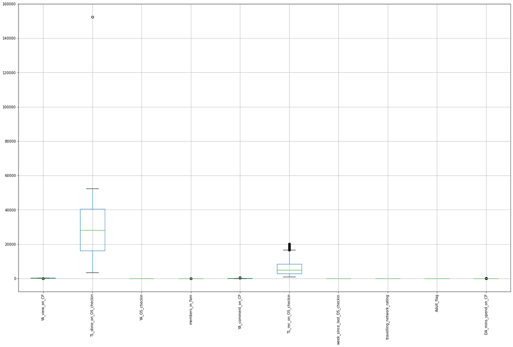

```python
#Detecting Outliers by making a box plot for numerical attributes

data.boxplot(figsize=(25, 15), rot=90)
```

There are few outliers in the data.

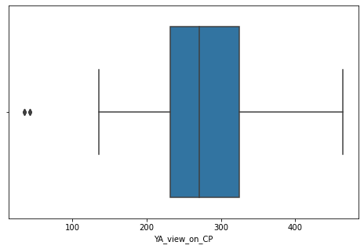

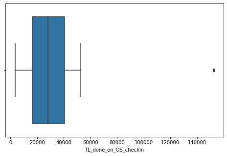

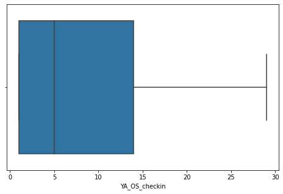

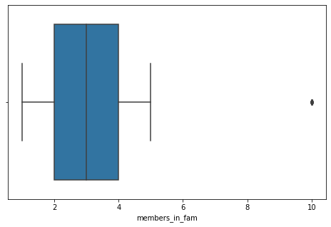

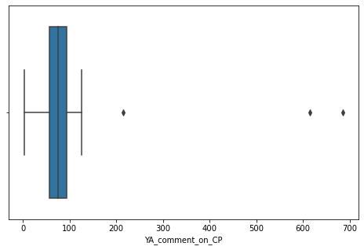

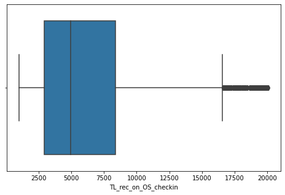

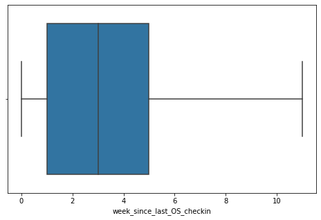

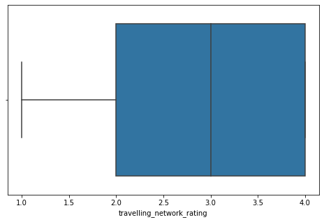

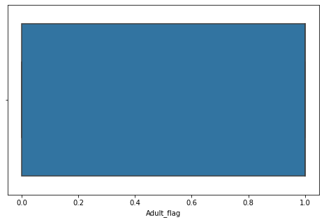

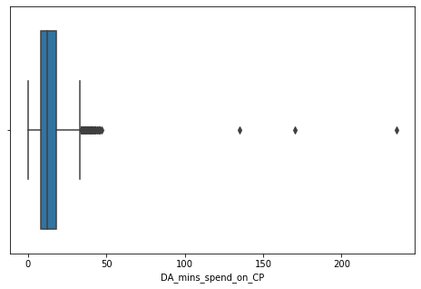

```python
#Let's look at them one by one for each numerical variables

num_columns = ['YA_view_on_CP' ,'TL_done_on_OS_checkin', 'YA_OS_checkin', 'members_in_fam', 'YA_comment_on_CP',
               'TL_rec_on_OS_checkin','week_since_last_OS_checkin','travelling_network_rating','Adult_flag',
               'DA_mins_spend_on_CP']

for col in num_columns:
    plt.figure(figsize=(8,5))
    sns.boxplot(data[col])
    plt.show()
```

#### Treating Outliers

Treating the outliers by using Inter Quartile Range (IQR) method.This technique uses the IQR scores to remove outliers. The rule of thumb is that anything not in the range of (Q1 - 1.5 IQR) and (Q3 + 1.5 IQR) is an outlier, and can be removed.

```python
#Calculating Q1 and Q3 values and assigning the upper limit (UL) and lower limit (LL)

Q1 = data[num_columns].quantile(0.25)
Q3 = data[num_columns].quantile(0.75)
IQR = Q3 - Q1
UL = Q3 + 1.5*IQR
LL = Q1 - 1.5*IQR
```

```python
#Sum of outliers in each column
pd.options.display.max_rows = None
((data[num_columns] > UL) | (data[num_columns] < LL)).sum()
```

```
YA_view_on_CP                   8
TL_done_on_OS_checkin           2
YA_OS_checkin                   0
members_in_fam                 10
YA_comment_on_CP                3
TL_rec_on_OS_checkin          818
week_since_last_OS_checkin      0
travelling_network_rating       0
Adult_flag                      0
DA_mins_spend_on_CP           315
dtype: int64
```

```python
#Total outliers

print('Total number of outliers in the dataset:',((data[num_columns] > UL) | (data[num_columns] < LL)).sum().sum())
```

```
Total number of outliers in the dataset: 1156
```

We will be defining a funtion named treat_outliers using that function we will remove those outliers.

```python
def treat_outliers(col):
    sorted(col)
    Q1,Q3=np.percentile(col,[25,75])
    IQR=Q3-Q1
    lower_range= Q1-(1.5 * IQR)
    upper_range= Q3+(1.5 * IQR)
    return lower_range, upper_range

for column in data[num_columns].columns:
    lr,ur=treat_outliers(data[column])
    data[column]=np.where(data[column]>ur,ur,data[column])
    data[column]=np.where(data[column]<lr,lr,data[column])
```

```python
#Now checking again.
((data[num_columns] > UL) | (data[num_columns] < LL)).sum()
```

```
YA_view_on_CP                 0
TL_done_on_OS_checkin         0
YA_OS_checkin                 0
members_in_fam                0
YA_comment_on_CP              0
TL_rec_on_OS_checkin          0
week_since_last_OS_checkin    0
travelling_network_rating     0
Adult_flag                    0
DA_mins_spend_on_CP           0
dtype: int64
```

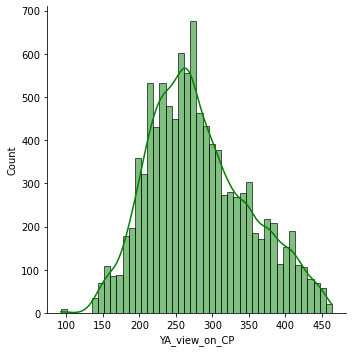

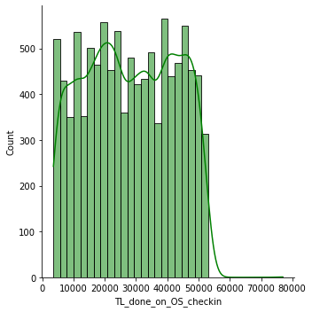

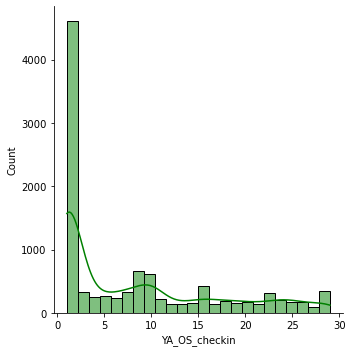

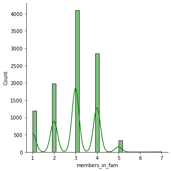

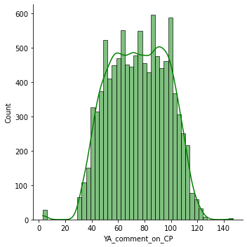

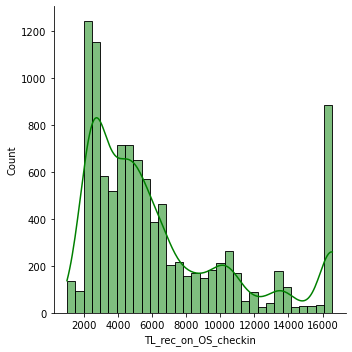

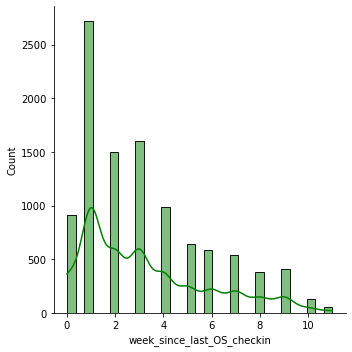

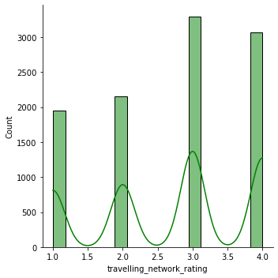

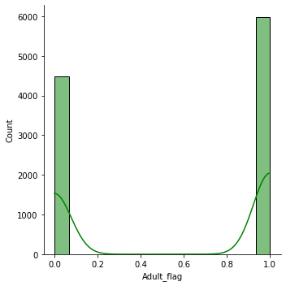

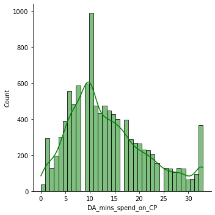

```python
for x in num_columns:
    plt.figure(figsize=(6,4))
    sns.displot(data[x], kde=True, color='green')
    plt.show()
```

### Bivariate Analysis

```python
#Now let see the correlation between the variables using correlation matrics

corr = data.corr()

corr
```

|  | YA_view_on_CP | TL_done_on_OS_checkin | YA_OS_checkin | members_in_fam | YA_comment_on_CP | TL_rec_on_OS_checkin | week_since_last_OS_checkin | travelling_network_rating | Adult_flag | DA_mins_spend_on_CP |
| --- | --- | --- | --- | --- | --- | --- | --- | --- | --- | --- |
| YA_view_on_CP | 1.00 | 0.01 | 0.01 | 0.20 | 0.04 | 0.50 | 0.29 | 0.05 | 0.09 | 0.64 |
| TL_done_on_OS_checkin | 0.01 | 1.00 | 0.00 | -0.01 | 0.01 | 0.01 | 0.04 | 0.00 | 0.03 | 0.02 |
| YA_OS_checkin | 0.01 | 0.00 | 1.00 | 0.02 | 0.06 | -0.00 | -0.03 | 0.01 | 0.04 | 0.01 |
| members_in_fam | 0.20 | -0.01 | 0.02 | 1.00 | 0.01 | 0.10 | 0.11 | -0.01 | 0.01 | 0.13 |
| YA_comment_on_CP | 0.04 | 0.01 | 0.06 | 0.01 | 1.00 | -0.01 | 0.06 | 0.00 | 0.04 | 0.07 |
| TL_rec_on_OS_checkin | 0.50 | 0.01 | -0.00 | 0.10 | -0.01 | 1.00 | 0.15 | 0.02 | 0.06 | 0.72 |
| week_since_last_OS_checkin | 0.29 | 0.04 | -0.03 | 0.11 | 0.06 | 0.15 | 1.00 | 0.05 | 0.02 | 0.28 |
| travelling_network_rating | 0.05 | 0.00 | 0.01 | -0.01 | 0.00 | 0.02 | 0.05 | 1.00 | -0.06 | 0.02 |
| Adult_flag | 0.09 | 0.03 | 0.04 | 0.01 | 0.04 | 0.06 | 0.02 | -0.06 | 1.00 | 0.07 |
| DA_mins_spend_on_CP | 0.64 | 0.02 | 0.01 | 0.13 | 0.07 | 0.72 | 0.28 | 0.02 | 0.07 | 1.00 |

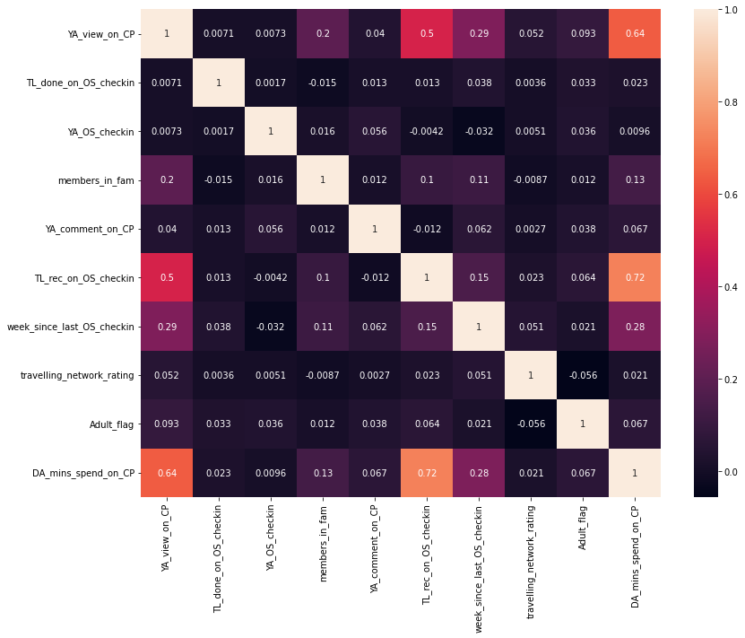

```python
#Heatmap

#Now we will plot the heatmap to display the correlation between the variables:

fig, ax = plt.subplots(figsize=(13,10))
sns.heatmap(corr,annot=True)
```

### So here in the above heatmap we can see that the light colours shows the highest correlation between 2 variables.

#### Highest correlated variables are :

1. 'TL_rec_on_OS_checkin' and 'DA_mins_spend_on_CP' (0.72)
2. 'YA_view_on_CP' and 'DA_mins_spend_on_CP' (0.64)
3. 'TL_rec_on_OS_checkin' and 'YA_view_on_CP' (0.5)

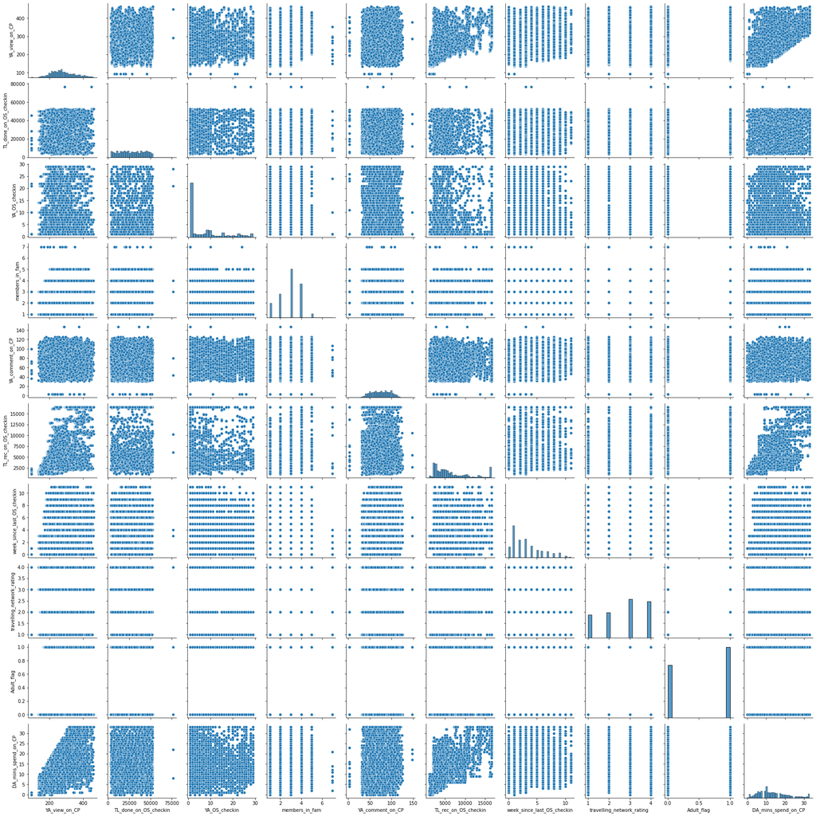

```python
#Pairplot

sns.pairplot(data)
```

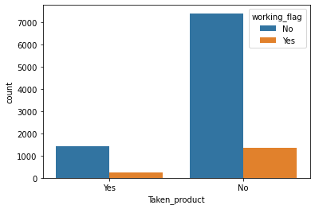

```python
#Countplot for Taken product with other variables to compare the relation

ax = sns.countplot(x="Taken_product", hue="working_flag", data=data)
```

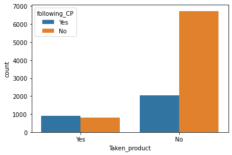

```python
#Taken_product with following_CP

ax = sns.countplot(x="Taken_product", hue="following_CP", data=data)
```